# 5300DTCWriteup

2022-08-26

## Libraries

This section loads all required libraries

```r
library(fixest)
library(tidyverse)
library(vtable)
library(lubridate)
library(ipumsr)
library(rdrobust)
library(dplyr)
library(ggplot2)
library(margins)
```

## Data Preperation and Wrangling

We pull all of our data from the IPUMS release of the Current Population Survey. We are interested in tracking employment impacts of the Covid Pandemic and therefore have pulled employment data from 2019 through 2021.

```r
ddi <- read_ipums_ddi("../data/cps_00006.xml")
emp_data <- read_ipums_micro(ddi)
```

```
## Use of data from IPUMS CPS is subject to conditions including that users should
## cite the data appropriately. Use command `ipums_conditions()` for more details.
```

```r
#Performing some initial type conversions to support later calculations.
emp_data$RACE <- as.character(emp_data$RACE) #Convert RACE into character type
emp_data$AGE <- as.numeric(emp_data$AGE)#Convert AGE into numeric type
emp_data$SEX <- as.character(emp_data$SEX) #Convert SEX into character type
emp_data$MARST <- as.character(emp_data$MARST) #Convert MARST into character type

# Filtering Dataset to Employed Individuals between 2019 and 2021 and creating an "Employment" flag to track employment status. Also filtering out military as they are not typically considered private sector "employed"
emp_data <- emp_data %>%
  drop_na(IND1990) %>%
  filter(YEAR>=2019 & YEAR <= 2021 & IND1990 > 000 & IND1990 < 940) %>%
  filter(LABFORCE == 2) %>%
  mutate(Employment = case_when(
    EMPSTAT == 10 | EMPSTAT == 12 ~ 1,
    TRUE ~ 0
  )) %>%
  mutate(Unemployed_experienced_worker = case_when(EMPSTAT == 21 ~ 1, TRUE ~ 0))%>%
  mutate(Unemployed_new_worker = case_when(EMPSTAT == 22 ~ 1, TRUE ~ 0))%>%

#Adding date column based off year and month of data and then using date field to calculate the week delta from the start of Covid, (all months after March 2020), utilizing this field to create a flag to track whether a value is Pre-Covid or Post-Covid.
  mutate(date = ymd(paste(YEAR, MONTH, "01"))) %>%
  mutate(weeks = as.numeric(difftime(date,ISOdate(2020,3,1), units="weeks"), units="weeks")) %>%
  mutate(yearmo = YEAR*100 + MONTH)%>%
  filter(MONTH != 3) %>%
  mutate(post_covid = case_when(
    weeks < 0 ~ 0,
    TRUE ~ 1
  )) %>%
  # https://cps.ipums.org/cps/codes/ind_2014_codes.shtml
  mutate(Industry = as.factor(case_when(
    IND1990 > 000 & IND1990 <= 032 ~ "AGRICULTURE, FORESTRY, AND FISHERIES",
    IND1990 >= 040 & IND1990 <= 050 ~ "MINING",
    IND1990 == 060 ~ "CONSTRUCTION",
    IND1990 >= 100 & IND1990 <= 392 ~ "MANUFACTURING",
    IND1990 >= 400 & IND1990 <= 472 ~ "TRANSPORTATION, COMMUNICATIONS, AND OTHER PUBLIC UTILITIES",
    IND1990 >= 500 & IND1990 <= 571 ~ "WHOLESALE TRADE",
    IND1990 >= 580 & IND1990 <= 691 ~ "RETAIL TRADE",
    IND1990 >= 700 & IND1990 <= 712 ~ "FINANCE, INSURANCE, AND REAL ESTATE",
    IND1990 >= 721 & IND1990 <= 760 ~ "BUSINESS AND REPAIR SERVICES",
    IND1990 >= 761 & IND1990 <= 791 ~ "PERSONAL SERVICES",
    IND1990 >= 800 & IND1990 <= 810 ~ "ENTERTAINMENT AND RECREATION SERVICES",
    IND1990 >= 812 & IND1990 <= 893 ~ "PROFESSIONAL AND RELATED SERVICES",
    IND1990 >= 900 & IND1990 <= 932 ~ "PUBLIC ADMINISTRATION",
    TRUE ~ "NIU"
  ))) %>%
  filter(Industry != "NIU") %>%
  mutate(Retail = Industry == "RETAIL TRADE")%>%
  mutate(Education = case_when(EDUC == 010 ~ 'high school or lower',
                               EDUC == 020 ~ 'high school or lower',
                               EDUC == 030 ~ 'high school or lower',
                               EDUC == 040 ~ 'high school or lower',
                               EDUC == 050 ~ 'high school or lower',
                               EDUC == 060 ~ 'high school or lower',
                               EDUC == 071 ~ 'high school or lower',
                               EDUC == 073 ~ 'high school or lower',
                               EDUC == 081 ~ 'college/associate/bachelor',
                               EDUC == 091 ~ 'college/associate/bachelor',
                               EDUC == 092 ~ 'college/associate/bachelor',
                               EDUC == 111 ~ 'college/associate/bachelor',
                               EDUC == 125 ~ 'doctorate', TRUE ~ 'NA')) %>%
  mutate(ClassofWorker = case_when(CLASSWKR == 13 ~ 'Self-employed',
                                   CLASSWKR == 14 ~ 'Self-employed',
                                   CLASSWKR == 22 ~ 'Private Profit',
                                   CLASSWKR == 23 ~ 'Private nonprofit',
                                   CLASSWKR == 25 ~ 'Federal government employee',
                                   CLASSWKR == 26 ~ 'Armed forces',
                                   CLASSWKR == 27 ~ 'State government employee',
                                   CLASSWKR == 28 ~ 'Local government employee', TRUE ~ 'NA'))%>%
  mutate(Workstatus = case_when(WKSTAT == 10 ~ 'full time',
                                           WKSTAT == 11 ~ 'full time',
                                           WKSTAT == 14 ~ 'full time',
                                           WKSTAT == 15 ~ 'full time',
                                           WKSTAT == 12 ~ 'part time',
                                           WKSTAT == 21 ~ 'part time',
                                           WKSTAT == 22 ~ 'part time',
                                           WKSTAT == 40 ~ 'part time',
                                           WKSTAT == 41 ~ 'part time', TRUE ~ 'Not at work'))%>%
  mutate(Age_broad = case_when(AGE >= 56 ~ '56-65',
                                          AGE >= 46 ~ '46-55',
                                          AGE >= 36 ~ '36-45',
                                          AGE >= 25 ~ '25-35', TRUE ~ 'NA'))%>%
  mutate(Occupation = case_when(OCC1990 <= 200 ~ 'MANAGERIAL AND PROFESSIONAL SPECIALTY OCCUPATIONS',
                                            OCC1990 <= 391 ~ 'TECHNICAL, SALES, AND ADMINISTRATIVE SUPPORT OCCUPATIONS',
                                            OCC1990 <= 469 ~ 'SERVICE OCCUPATIONS',
                                            OCC1990 <= 498 ~ 'FARMING, FORESTRY, AND FISHING OCCUPATIONS',
                                            OCC1990 <= 699 ~ 'PRECISION PRODUCTION, CRAFT, AND REPAIR OCCUPATIONS',
                                            OCC1990 <= 890 ~ 'OPERATORS, FABRICATORS, AND LABORERS',
                                            OCC1990 == 905 ~ 'MILITARY OCCUPATIONS', TRUE ~ 'NA'))
```

## Aggregations

```r
# Isolating retail
data_retail <- emp_data %>%
  filter(Retail == 1)

# Isolating non-retail
data_non_retail <- emp_data %>%
  filter(Retail != 1)

# Summarizing by retail[T/F] by date
data_ret_summ <- emp_data %>%
  group_by(date, weeks, Retail) %>%
  summarise(Employment=mean(Employment))

#Aggregate the total count of unemployed_experienced_worker, unemployed-new worker
df_Employed <- emp_data %>% drop_na(Industry) %>% group_by(yearmo, Industry) %>% summarise(Count = sum(Employment))
df_unemployed_experienced <- emp_data %>% drop_na(Industry) %>% group_by(yearmo, Industry) %>% summarise(Count = sum(Unemployed_experienced_worker))
df_unemployed_new <- emp_data %>%  group_by(yearmo, Industry) %>% summarise(Count = sum(Unemployed_new_worker))

#Check the education attainments of employed and unemployed workers
df_Employed_EDUC <- emp_data %>% filter(Education != 'NA') %>% group_by(yearmo, Education) %>% summarise(Count = sum(Employment))
df_unemployed_experienced_EDUC <- emp_data %>% filter(Education != 'NA') %>% group_by(yearmo, Education) %>% summarise(Count = sum(Unemployed_experienced_worker))
df_unemployed_new_EDUC <- emp_data %>% filter(Education != 'NA') %>% group_by(yearmo, Education) %>% summarise(Count = sum(Unemployed_new_worker))

#Check the Worker Class of employed and umemployed workers
df_Employed_WorkerClass <- emp_data %>% filter(ClassofWorker != 'NA') %>% group_by(yearmo, ClassofWorker) %>% summarise(Count = sum(Employment))
df_unemployed_experienced_WorkerClass <- emp_data %>% filter(ClassofWorker != 'NA') %>% group_by(yearmo, ClassofWorker) %>% summarise(Count = sum(Unemployed_experienced_worker))
df_unemployed_new_WorkerClass <- emp_data %>% filter(ClassofWorker != 'NA') %>% group_by(yearmo, ClassofWorker) %>% summarise(Count = sum(Unemployed_new_worker))

#Check the Work Status of employed and umemployed workers
df_Employed_Workstatus <- emp_data %>% group_by(yearmo, Workstatus) %>% summarise(Count = sum(Employment))
df_unemployed_experienced_Workstatus <- emp_data %>% group_by(yearmo, Workstatus) %>% summarise(Count = sum(Unemployed_experienced_worker))
df_unemployed_new_Workstatus <- emp_data %>% group_by(yearmo, Workstatus) %>% summarise(Count = sum(Unemployed_new_worker))

#Check the different Age range of employed and umemployed workers situation
df_Employed_Age <- emp_data %>% group_by(yearmo, Age_broad) %>% summarise(Count = sum(Employment))
df_unemployed_experienced_Age <- emp_data %>% group_by(yearmo, Age_broad) %>% summarise(Count = sum(Unemployed_experienced_worker))
df_unemployed_new_Age <- emp_data %>% group_by(yearmo, Age_broad) %>% summarise(Count = sum(Unemployed_new_worker))

#Check gender of employed and umemployed workers situation
df_Employed_Sex <- emp_data %>% group_by(yearmo, SEX) %>% summarise(Count = sum(Employment))
df_unemployed_experienced_Sex <- emp_data %>% group_by(yearmo, SEX) %>% summarise(Count = sum(Unemployed_experienced_worker))
df_unemployed_new_Sex <- emp_data %>% group_by(yearmo, SEX) %>% summarise(Count = sum(Unemployed_new_worker))

#Check Race distribution of employed and umemployed workers situation
df_Employed_Race <- emp_data %>% group_by(yearmo, RACE) %>% summarise(Count = sum(Employment))
df_unemployed_experienced_RACE <- emp_data %>% group_by(yearmo, RACE) %>% summarise(Count = sum(Unemployed_experienced_worker))
df_unemployed_new_RACE <- emp_data %>% group_by(yearmo, RACE) %>% summarise(Count = sum(Unemployed_new_worker))

#Check Marital status
df_Employed_Marital <- emp_data %>% filter(MARST != 9) %>% group_by(yearmo, MARST) %>% summarise(Count = sum(Employment))
df_unemployed_experienced_Marital <- emp_data %>% filter(MARST != 9) %>% group_by(yearmo, MARST) %>% summarise(Count = sum(Unemployed_experienced_worker))
df_unemployed_new_Marital <- emp_data %>% filter(MARST != 9) %>% group_by(yearmo, MARST) %>% summarise(Count = sum(Unemployed_new_worker))

#Check how's the employed, unemployed situation in different occupation
df_Employed_Occupation <- emp_data %>% filter(Occupation != 'NA') %>% group_by(yearmo, Occupation) %>% summarise(Count = sum(Employment))
df_unemployed_experienced_Occupation <- emp_data %>% filter(Occupation != 'NA') %>% group_by(yearmo, Occupation) %>% summarise(Count = sum(Unemployed_experienced_worker))
df_unemployed_new_Occupation <- emp_data %>%  group_by(yearmo, Occupation) %>% summarise(Count = sum(Unemployed_new_worker))
```

## Question One - The impact of Covid on Retail Employment

The first part of the analysis utilized employment data to explore the effect of Covid on the health of the retail industry.

```r
#We roll up employment to the month level for analysis
q1_data <- data_retail %>% group_by(date, post_covid) %>%
  summarize(monthly_employment = sum(Employment))

sumtable(q1_data)
```

Summary Statistics

| Variable | N | Mean | Std. Dev. | Min | Pctl. 25 | Pctl. 75 | Max |
| --- | --- | --- | --- | --- | --- | --- | --- |
| post_covid | 22 | 0.5 | 0.512 | 0 | 0 | 1 | 1 |
| monthly_employment | 22 | 5555.864 | 862.823 | 3969 | 5277 | 6279 | 6344 |

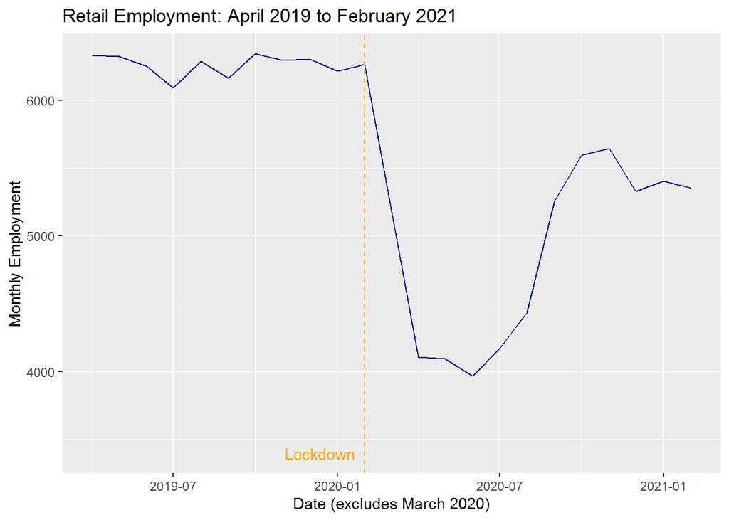

```r
q1_data %>% ggplot(aes(date, monthly_employment)) +
  geom_line(color = "dark blue") +
  ggtitle("Retail Employment: April 2019 to February 2021") +
  geom_vline(xintercept = as.Date("2020-02-01") - 0.5,
             col = "orange",
             linetype = "dashed"
  ) +
  xlab("Date (excludes March 2020)") +
  ylab("Monthly Employment") +

  annotate(geom = "text",
           x = as.Date("2020-02-01") -50,
           y = 3400,
           label = "Lockdown",
           color = "orange")
```

```r
q1_data_month <- q1_data %>%
  filter(month(date) > 2) %>%
  mutate(month = factor(month(date),levels = c(4:12)),
         year = factor(year(date)),
         post_covid = case_when(post_covid == 1 ~ "Post",
                               TRUE ~ "Pre"))
```

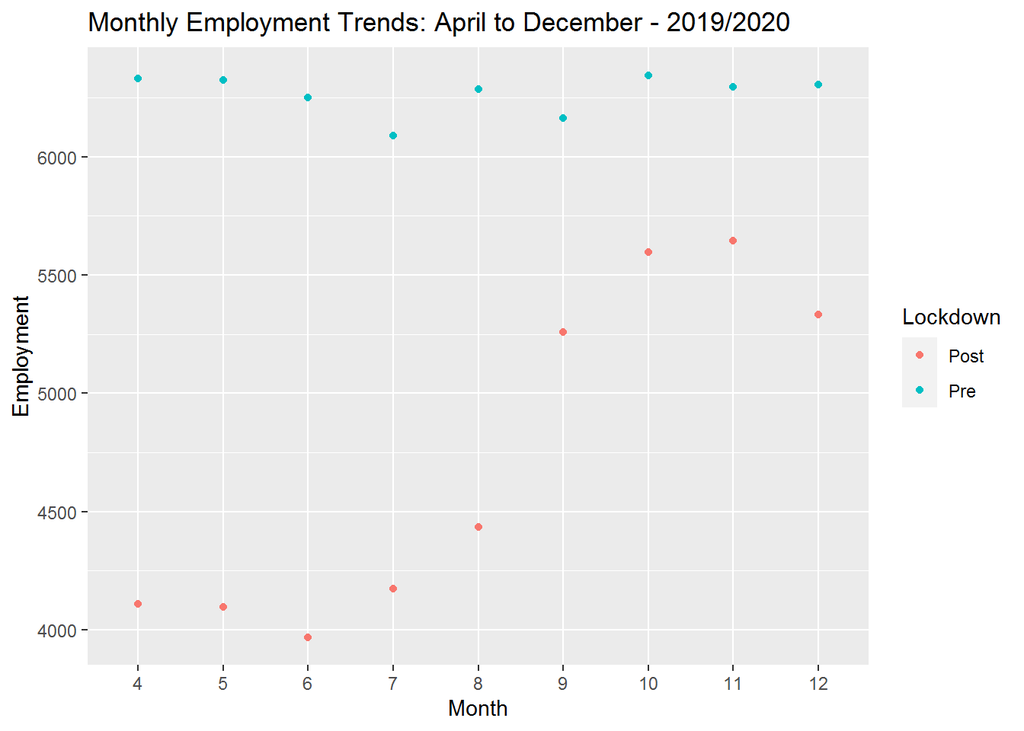

```r
q1_data_month %>% ggplot(aes(x = month,
                             y = monthly_employment,
                             col = post_covid)) +
  geom_point() +
  ggtitle("Monthly Employment Trends: April to December - 2019/2020") +
  labs(col = "Lockdown") +
  xlab("Month") +
  ylab("Employment")
```

```r
q1_m1 <-  q1_data %>% feols(monthly_employment ~ post_covid)
etable(q1_m1)
```

```
##                               q1_m1
## Dependent Var.:  monthly_employment
##
## (Intercept)        6,260*** (146.6)
## post_covid      -1,408.3*** (207.3)
## _______________ ___________________
## S.E. type                       IID
## Observations                     22
## R2                          0.69771
## Adj. R2                     0.68259
## ---
## Signif. codes: 0 '***' 0.001 '**' 0.01 '*' 0.05 '.' 0.1 ' ' 1
```

The retail industry saw a drop in monthly employment of 1,408 people post-lockdown, a decrease of 22%. This was statistically significant at an alpha of 0.001. Thus, based on the model, there is strong evidence that the lockdown had a negative impact on the health of the retail industry.

This conclusion is contingent on the assumption that the drop was due to the lockdown and not other factors. This assumption is backed up in the “Retail Employment” graph which shows a steep decline in employment following the lockdown measures in March 2020. Additionally, employment then proceeds to climb upwards as stores reopened in the months following. The “Monthly Employment Trends” graph further supports this assumption, as after lockdown restrictions eased up throughout the summer of 2020, September to November have similar trends compared to the same span in the previous year.

## Question Two - Covid Impact on Retail vs Other Organizations

The second research question is investigating if retail employment differed from other industries. Several data transformations were generated to compare:

1. Industry groupings based on the IND1990 categories found here: https://cps.ipums.org/cps-action/variables/IND1990#codes_section
2. Filtering out Not In Universe and Military jobs to focus on the private sector
3. A binary variable that is TRUE when the industry is retail, and FALSE otherwise
4. Aggregated monthly employment rates by industry
5. Since the lock down began mid-March, all data from March 2020 is filtered out to prevent issues due to reporting inconsistencies

For reference, the average employment rates by industry are as follows:

```r
# Aggregating monthly data and ensuring
Q2_data_mo <- emp_data %>%
  filter(Industry != "NIU" & Industry != "ACTIVE DUTY MILITARY") %>%
  group_by(Industry, date, Retail, weeks, post_covid) %>%
  summarise(Employment = mean(Employment))

Q2_data_mo %>%
  group_by(Industry) %>%
  summarize("Employment Rate" = mean(Employment))
```

```
## # A tibble: 13 x 2
##    Industry                                                   `Employment Rate`
##    <fct>                                                                  <dbl>
##  1 AGRICULTURE, FORESTRY, AND FISHERIES                                   0.955
##  2 BUSINESS AND REPAIR SERVICES                                           0.944
##  3 CONSTRUCTION                                                           0.939
##  4 ENTERTAINMENT AND RECREATION SERVICES                                  0.870
##  5 FINANCE, INSURANCE, AND REAL ESTATE                                    0.973
##  6 MANUFACTURING                                                          0.956
##  7 MINING                                                                 0.922
##  8 PERSONAL SERVICES                                                      0.887
##  9 PROFESSIONAL AND RELATED SERVICES                                      0.964
## 10 PUBLIC ADMINISTRATION                                                  0.981
## 11 RETAIL TRADE                                                           0.924
## 12 TRANSPORTATION, COMMUNICATIONS, AND OTHER PUBLIC UTILITIES             0.948
## 13 WHOLESALE TRADE                                                        0.961
```

## Plots

A graph of each industry’s employment rate over time shows differences across industries:

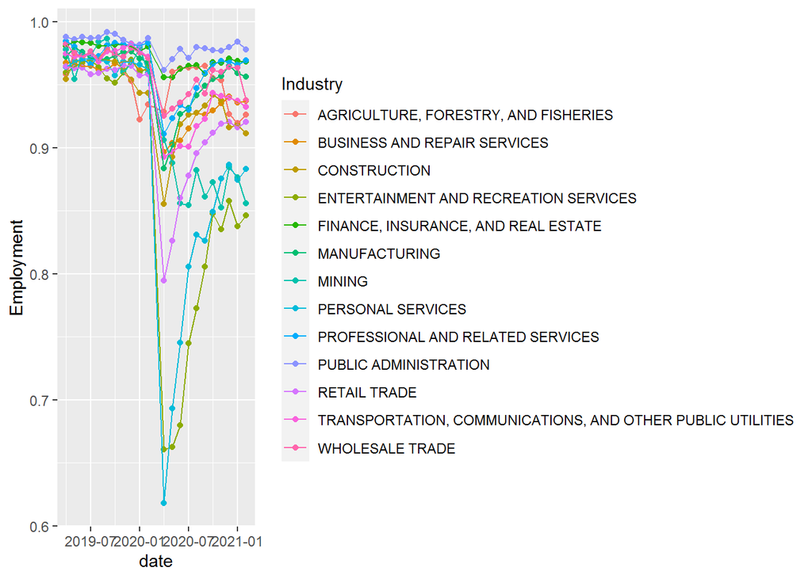

```r
ggplot(data = Q2_data_mo, aes(x=date, y=Employment, colour=Industry, group=Industry)) +
  geom_point() + geom_line()
```

While retail did not exhibit the strongest declines, it appears to have declined drastically more than the strongest and indeed was the third worst according to this graph.

Isolating Retail vs all other industries helps visualize this difference:

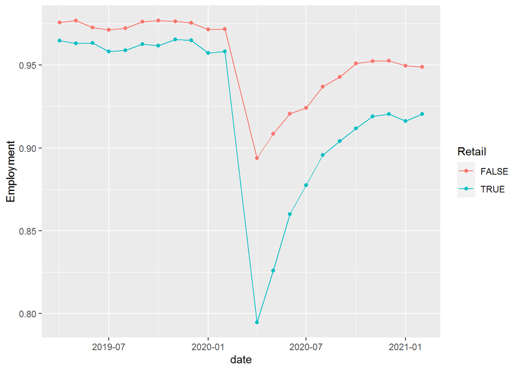

```r
ggplot(data=data_ret_summ, aes(x=date, y=Employment, colour=Retail)) +
  geom_point() +
  geom_line() +
  geom_vline(xintercept=ISOdate(2020,3,1))
```

While pre-pandemic employment is a bit lower for retail than other industries, the overall trend looks very similar. However, the decline immediately after lock downs was greater both absolutely and proportionately.

Next, rdplots were generated at first and second orders, for all industries and retail alone.

```
## [1] "Mass points detected in the running variable."
```

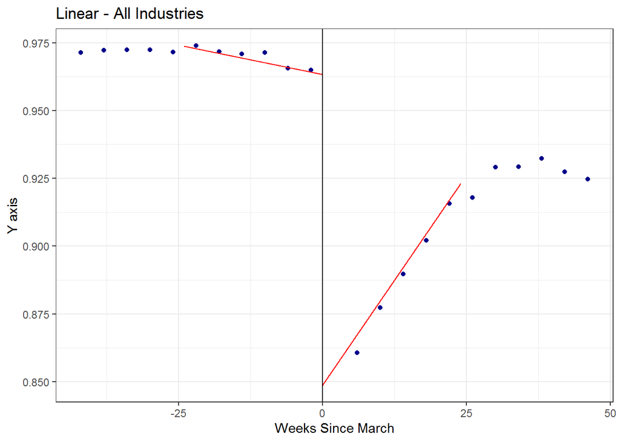

```r
rdplot(Q2_data_mo$Employment, Q2_data_mo$weeks, c=0, p=1, h=24, kernel = "uniform",
       title = "Linear - All Industries", x.label = "Weeks Since March")
```

```
## [1] "Mass points detected in the running variable."
```

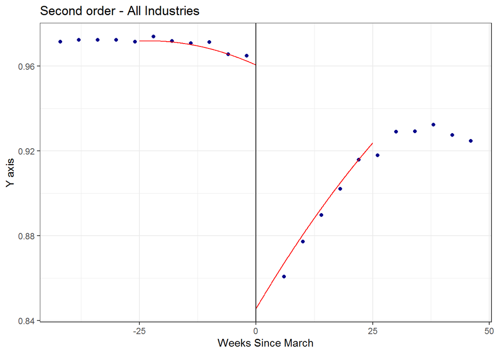

```r
rdplot(Q2_data_mo$Employment, Q2_data_mo$weeks, c=0, p=2, h=25, kernel = "uniform",
       title = "Second order - All Industries", x.label = "Weeks Since March")
```

```
## [1] "Mass points detected in the running variable."
```

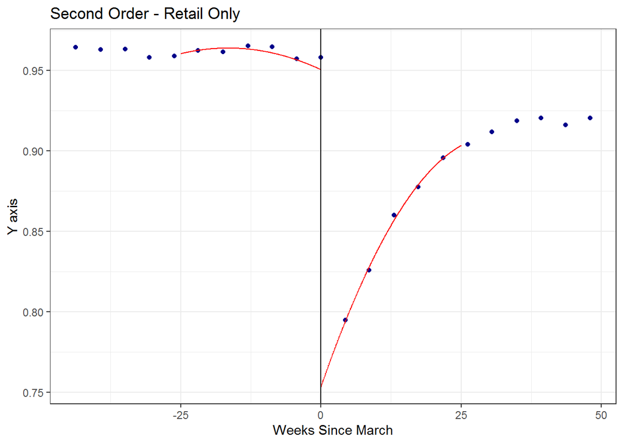

```r
rdplot(data_retail$Employment, data_retail$weeks, c=0, p=2, h=25, kernel = "uniform",
       title = "Second Order - Retail Only", x.label = "Weeks Since March")
```

## Models

Several models were created to analyze the pandemic, starting with a fixed effect ols model regressing employment by date and pre/post pandemic, with fixed effects applied by Industry:

```r
model_1 <- feols(Employment ~ weeks * post_covid | Industry, data=Q2_data_mo, vcov="hetero")
etable(model_1)
```

```
##                                model_1
## Dependent Var.:             Employment
##
## weeks                 -0.0001 (0.0002)
## post_covid         -0.0965*** (0.0121)
## weeks x post_covid  0.0016*** (0.0004)
## Fixed-Effects:     -------------------
## Industry                           Yes
## __________________ ___________________
## S.E. type          Heteroskedast.-rob.
## Observations                       286
## R2                             0.64273
## Within R2                      0.49332
## ---
## Signif. codes: 0 '***' 0.001 '**' 0.01 '*' 0.05 '.' 0.1 ' ' 1
```

```r
wald(model_1)
```

```
## Wald test, H0: joint nullity of weeks, post_covid and weeks:post_covid
##  stat = 81.9, p-value < 2.2e-16, on 3 and 270 DoF, VCOV: Heteroskedasticity-robust.
```

The Wald test shows statistically significant coefficients by industry, but we can investigate further to provide more context via different methods.

Noting that weeks was not individually statistically significant to the model, four more models were generated using both rdrobust and feols to compare different structures:

```r
model_2 <- feols(Employment ~ weeks * post_covid | Retail, data=Q2_data_mo, se="hetero")
model_2_rd_r <- rdrobust(data_retail$Employment, data_retail$weeks, c=0, p=2, h=25, kernel = "uniform")
model_2_rd_nr <- rdrobust(data_non_retail$Employment, data_non_retail$weeks, c=0, p=2, h=25, kernel = "uniform")
model_3 <- feols(Employment ~ post_covid * Industry, data = Q2_data_mo, se="hetero")
```

Comparing the three feols() models:

```r
etable(model_1, model_2)
```

```
##                                model_1             model_2
## Dependent Var.:             Employment          Employment
##
## weeks                 -0.0001 (0.0002)  -0.0001. (7.35e-5)
## post_covid         -0.0965*** (0.0121) -0.0965*** (0.0156)
## weeks x post_covid  0.0016*** (0.0004)  0.0016*** (0.0005)
## Fixed-Effects:     ------------------- -------------------
## Industry                           Yes                  No
## Retail                              No                 Yes
## __________________ ___________________ ___________________
## S.E. type          Heteroskedast.-rob. Heteroskedast.-rob.
## Observations                       286                 286
## R2                             0.64273             0.35462
## Within R2                      0.49332             0.35021
## ---
## Signif. codes: 0 '***' 0.001 '**' 0.01 '*' 0.05 '.' 0.1 ' ' 1
```

```r
etable(model_3)
```

```
##                                                                                        model_3
## Dependent Var.:                                                                     Employment
##
## (Intercept)                                                                 0.9613*** (0.0056)
## post_covid                                                                   -0.0136. (0.0078)
## IndustryBUSINESSANDREPAIRSERVICES                                              0.0037 (0.0056)
## IndustryCONSTRUCTION                                                          -0.0002 (0.0064)
## IndustryENTERTAINMENTANDRECREATIONSERVICES                                     0.0010 (0.0058)
## IndustryFINANCE,INSURANCE,ANDREALESTATE                                     0.0200*** (0.0056)
## IndustryMANUFACTURING                                                         0.0116* (0.0057)
## IndustryMINING                                                                0.0106. (0.0064)
## IndustryPERSONALSERVICES                                                       0.0052 (0.0057)
## IndustryPROFESSIONALANDRELATEDSERVICES                                       0.0173** (0.0059)
## IndustryPUBLICADMINISTRATION                                                0.0254*** (0.0056)
## IndustryRETAILTRADE                                                            0.0003 (0.0056)
## IndustryTRANSPORTATION,COMMUNICATIONS,ANDOTHERPUBLICUTILITIES                 0.0138* (0.0057)
## IndustryWHOLESALETRADE                                                        0.0138* (0.0057)
## post_covid x IndustryBUSINESSANDREPAIRSERVICES                              -0.0285** (0.0091)
## post_covid x IndustryCONSTRUCTION                                           -0.0313** (0.0112)
## post_covid x IndustryENTERTAINMENTANDRECREATIONSERVICES                    -0.1713*** (0.0250)
## post_covid x IndustryFINANCE,INSURANCE,ANDREALESTATE                          -0.0036 (0.0080)
## post_covid x IndustryMANUFACTURING                                           -0.0207. (0.0111)
## post_covid x IndustryMINING                                                -0.0865*** (0.0099)
## post_covid x IndustryPERSONALSERVICES                                      -0.1450*** (0.0276)
## post_covid x IndustryPROFESSIONALANDRELATEDSERVICES                           -0.0158 (0.0103)
## post_covid x IndustryPUBLICADMINISTRATION                                      0.0028 (0.0081)
## post_covid x IndustryRETAILTRADE                                           -0.0621*** (0.0151)
## post_covid x IndustryTRANSPORTATION,COMMUNICATIONS,ANDOTHERPUBLICUTILITIES -0.0411*** (0.0099)
## post_covid x IndustryWHOLESALETRADE                                           -0.0145 (0.0090)
## ________________________________________                                   ___________________
## S.E. type                                                                  Heteroskedast.-rob.
## Observations                                                                               286
## R2                                                                                     0.79236
## Adj. R2                                                                                0.77239
## ---
## Signif. codes: 0 '***' 0.001 '**' 0.01 '*' 0.05 '.' 0.1 ' ' 1
```

These three models show mostly statistically significant coefficients, and a respectable R2 when regressing Employment on post_covid (i.e. has the pandemic happened) and industry in model_3.

The rdrobust models allow for more targeted analysis of second order models, controlling for retail:

```r
summary(model_2_rd_r, vcov="hetero")
```

```
## Sharp RD estimates using local polynomial regression.
##
## Number of Obs.               131658
## BW type                      Manual
## Kernel                      Uniform
## VCE method                       NN
##
## Number of Obs.                71605        60053
## Eff. Number of Obs.           32679        24452
## Order est. (p)                    2            2
## Order bias  (q)                   3            3
## BW est. (h)                  25.000       25.000
## BW bias (b)                  25.000       25.000
## rho (h/b)                     1.000        1.000
## Unique Obs.                   71605        60053
##
## =============================================================================
##         Method     Coef. Std. Err.         z     P>|z|      [ 95% C.I. ]
## =============================================================================
##   Conventional    -0.197     0.013   -15.637     0.000    [-0.222 , -0.173]
##         Robust         -         -    -7.363     0.000    [-0.268 , -0.155]
## =============================================================================
```

```r
summary(model_2_rd_nr, vcov="hetero")
```

```
## Sharp RD estimates using local polynomial regression.
##
## Number of Obs.               854280
## BW type                      Manual
## Kernel                      Uniform
## VCE method                       NN
##
## Number of Obs.               457246       397034
## Eff. Number of Obs.          208367       168673
## Order est. (p)                    2            2
## Order bias  (q)                   3            3
## BW est. (h)                  25.000       25.000
## BW bias (b)                  25.000       25.000
## rho (h/b)                     1.000        1.000
## Unique Obs.                  457246       397034
##
## =============================================================================
##         Method     Coef. Std. Err.         z     P>|z|      [ 95% C.I. ]
## =============================================================================
##   Conventional    -0.089     0.004   -23.502     0.000    [-0.097 , -0.082]
##         Robust         -         -   -13.015     0.000    [-0.129 , -0.096]
## =============================================================================
```

Finally, individual models were created for each industry to demonstrate individual comparisons. Additional work could be conducted to precisely identify the significance of differences between pairs of industries, but the conclusion above was determined to sufficiently answer the research question at hand.

```r
IndList <- split(Q2_data_mo, f=Q2_data_mo$Industry)
model_list <- list()
rdrobust_list <- list()

for (i in 1:length(IndList)) {
  indus <- levels(IndList[[i]]$Industry)[i]
  modelname <- paste0(indus, "_model") %>%
    replace(" ", "_")

  model_list[[paste0(indus)]] <- assign(modelname,feols(Employment ~ weeks * post_covid, data=IndList[[i]]))
  rdrobust_list[[paste0(indus)]] <- assign(modelname,rdrobust(IndList[[i]]$Employment,IndList[[i]]$weeks,c=0,p=2,h=25,kernel="uniform"))
}

etable(model_list)
```

```
##                    AGRICULTURE, FOR.. BUSINESS AND REPA..       CONSTRUCTION
## Dependent Var.:            Employment          Employment         Employment
##
## (Intercept)        0.9388*** (0.0100)  0.9636*** (0.0027) 0.9492*** (0.0108)
## weeks               -0.0009* (0.0003)  -5.63e-5 (9.24e-5)   -0.0005 (0.0004)
## post_covid           0.0259. (0.0141) -0.0665*** (0.0039) -0.0556** (0.0153)
## weeks x post_covid    0.0002 (0.0005)  0.0010*** (0.0001)   0.0013* (0.0005)
## __________________ __________________ ___________________ __________________
## S.E. type                         IID                 IID                IID
## Observations                       22                  22                 22
## R2                            0.44692             0.97337            0.72162
## Adj. R2                       0.35474             0.96893            0.67523
##
##                    ENTERTAINMENT AND.. FINANCE, INSURANC..       MANUFACTURING
## Dependent Var.:             Employment          Employment          Employment
##
## (Intercept)         0.9610*** (0.0141)  0.9791*** (0.0016)  0.9706*** (0.0057)
## weeks                -4.95e-5 (0.0005)  -8.79e-5 (5.26e-5)   -8.99e-5 (0.0002)
## post_covid         -0.3153*** (0.0200) -0.0230*** (0.0022) -0.0739*** (0.0081)
## weeks x post_covid  0.0051*** (0.0007) 0.0004*** (7.44e-5)  0.0017*** (0.0003)
## __________________ ___________________ ___________________ ___________________
## S.E. type                          IID                 IID                 IID
## Observations                        22                  22                  22
## R2                             0.96549             0.94642             0.89392
## Adj. R2                        0.95974             0.93749             0.87624
##
##                                 MINING   PERSONAL SERVICES PROFESSIONAL AND ..
## Dependent Var.:             Employment          Employment          Employment
##
## (Intercept)         0.9690*** (0.0091)  0.9641*** (0.0179)  0.9826*** (0.0046)
## weeks                 -0.0001 (0.0003)   -9.37e-5 (0.0006)     0.0001 (0.0002)
## post_covid         -0.0851*** (0.0129) -0.2993*** (0.0253) -0.0694*** (0.0065)
## weeks x post_covid    -0.0004 (0.0004)  0.0056*** (0.0009)  0.0012*** (0.0002)
## __________________ ___________________ ___________________ ___________________
## S.E. type                          IID                 IID                 IID
## Observations                        22                  22                  22
## R2                             0.93912             0.93579             0.90651
## Adj. R2                        0.92898             0.92509             0.89092
##
##                    PUBLIC ADMINISTRA..        RETAIL TRADE TRANSPORTATION, C..
```

[output cut: 11 more lines]

```
##
##                        WHOLESALE TRADE
## Dependent Var.:             Employment
##
## (Intercept)         0.9731*** (0.0052)
## weeks                -7.74e-5 (0.0002)
## post_covid         -0.0435*** (0.0074)
## weeks x post_covid   0.0007** (0.0003)
## __________________ ___________________
## S.E. type                          IID
## Observations                        22
## R2                             0.81637
## Adj. R2                        0.78576
## ---
## Signif. codes: 0 '***' 0.001 '**' 0.01 '*' 0.05 '.' 0.1 ' ' 1
```

```r
for (i in 1:length(rdrobust_list)) {
  print(names(rdrobust_list)[i])
  summary(rdrobust_list[[i]])
}
```

```
## [1] "AGRICULTURE, FORESTRY, AND FISHERIES"
## Sharp RD estimates using local polynomial regression.
##
## Number of Obs.                   22
## BW type                      Manual
## Kernel                      Uniform
## VCE method                       NN
##
## Number of Obs.                   11           11
## Eff. Number of Obs.               5            5
## Order est. (p)                    2            2
## Order bias  (q)                   3            3
## BW est. (h)                  25.000       25.000
## BW bias (b)                  25.000       25.000
## rho (h/b)                     1.000        1.000
## Unique Obs.                      11           11
##
## =============================================================================
##         Method     Coef. Std. Err.         z     P>|z|      [ 95% C.I. ]
## =============================================================================
##   Conventional    -0.026     0.057    -0.455     0.649    [-0.136 , 0.085]
##         Robust         -         -    -0.958     0.338    [-0.351 , 0.121]
## =============================================================================
## [1] "BUSINESS AND REPAIR SERVICES"
## Sharp RD estimates using local polynomial regression.
##
## Number of Obs.                   22
## BW type                      Manual
## Kernel                      Uniform
## VCE method                       NN
##
## Number of Obs.                   11           11
## Eff. Number of Obs.               5            5
## Order est. (p)                    2            2
## Order bias  (q)                   3            3
## BW est. (h)                  25.000       25.000
## BW bias (b)                  25.000       25.000
## rho (h/b)                     1.000        1.000
## Unique Obs.                      11           11
##
```

[output cut: 244 more lines]

```
## Number of Obs.                   11           11
## Eff. Number of Obs.               5            5
## Order est. (p)                    2            2
## Order bias  (q)                   3            3
## BW est. (h)                  25.000       25.000
## BW bias (b)                  25.000       25.000
## rho (h/b)                     1.000        1.000
## Unique Obs.                      11           11
##
## =============================================================================
##         Method     Coef. Std. Err.         z     P>|z|      [ 95% C.I. ]
## =============================================================================
##   Conventional    -0.043     0.022    -1.974     0.048    [-0.086 , -0.000]
##         Robust         -         -    -1.045     0.296    [-0.114 , 0.035]
## =============================================================================
```

Looking at the etable output, we see that only Personal Services and Entertainment industries exhibited greater declines in employment than Retail. As noted above, additional analysis should be conducted if the magnitude and significant of these specific differences is of interest.

## Question Three - Changes in employment and consumer spending post-lockdown

## High Level Frequency stats

Next, frequency stats were added to view the dispersion of our binary dependent variable. As per the table, majority class across the board is employed, and thus there was no large differences in employment among demographic traits, martial status, or industry that was clearly visible.

Because the following factor variables will be used as dummy variables down stream, other variables were removed from the analysis (i.e. to avoid making a dummy variable where a single person is employed in a niche market as this adds more features with little importance).

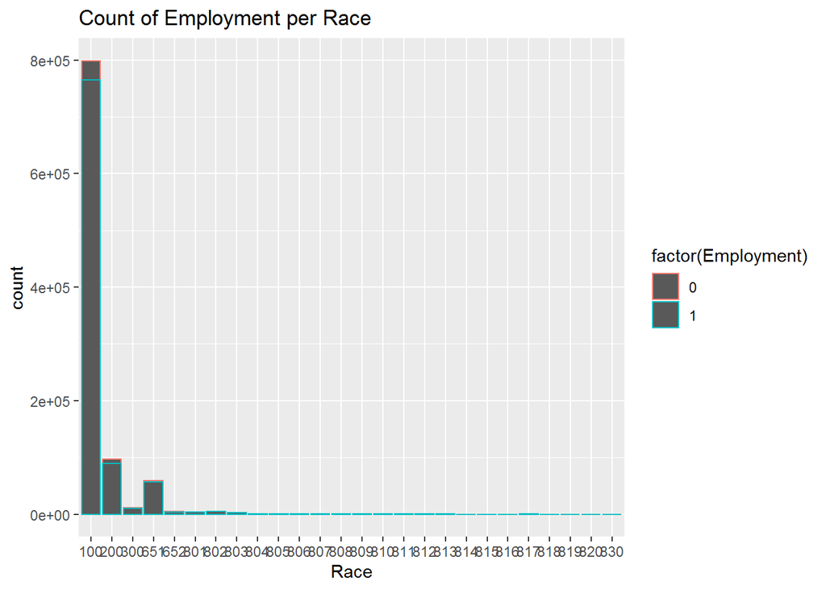

```r
ggplot(emp_data, aes(x= RACE, color = factor(Employment))) + geom_bar() +
  ggtitle("Count of Employment per Race") +
  xlab("Race")
```

$Note:$ Looking at break out by race, there are some counts that could add noise to the data and create many dummy variables. Thus, the sample was adjusted to the top 10 `RACE` demographics in terms of employment population.

```r
emp_data %>%
  group_by(RACE) %>%
  summarise(rec_count = n()) %>%
  arrange(., desc(rec_count))
```

```
## # A tibble: 26 x 2
##    RACE  rec_count
##    <chr>     <int>
##  1 100      799025
##  2 200       96484
##  3 651       59454
##  4 300       11058
##  5 802        5142
##  6 652        4387
##  7 801        3901
##  8 803        2994
##  9 805         696
## 10 804         678
## # ... with 16 more rows
```

```r
emp_racedf <- emp_data %>%
  filter(RACE == c(100,200,300,651,802,652,801,803,805,804))
```

Looking at employment by industry

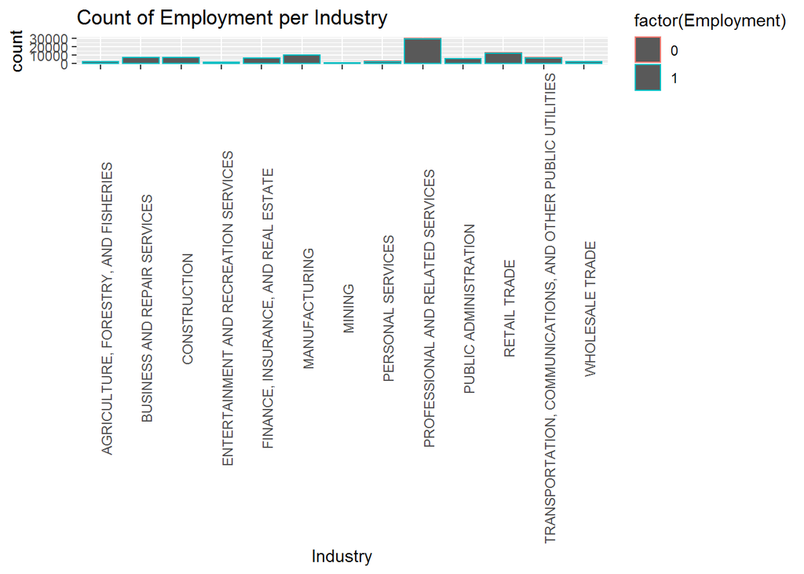

```r
ggplot(emp_racedf, aes(x= Industry, color = factor(Employment))) + geom_bar() +
  ggtitle("Count of Employment per Industry") +
  theme(axis.text.x = element_text(angle = 90
                                   )) +
  ggtitle("Count of Employment per Industry") +
  xlab("Industry")
```

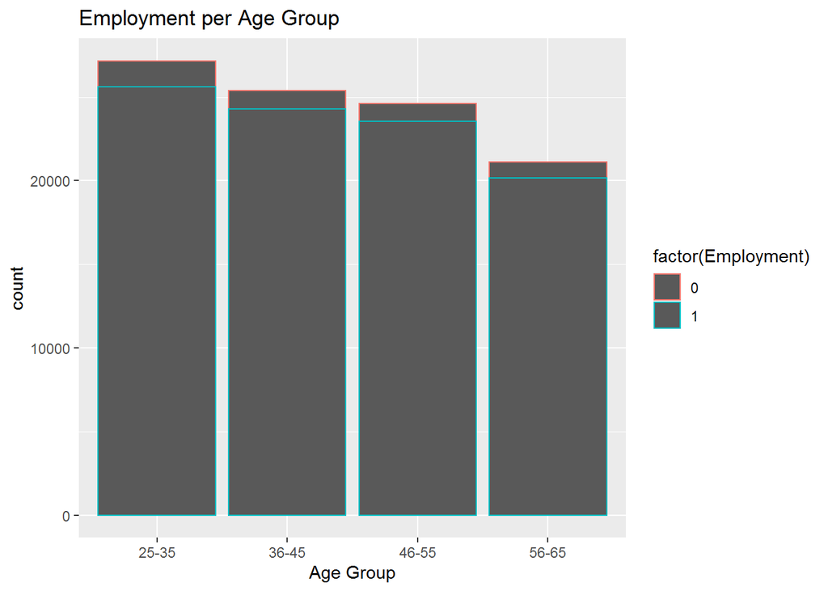

```r
ggplot(emp_racedf, aes(x= Age_broad, color = factor(Employment))) + geom_bar() +
  ggtitle("Employment per Age Group") +
  xlab("Age Group")
```

$Note:$: Age shows no large discrepancies, with employment.

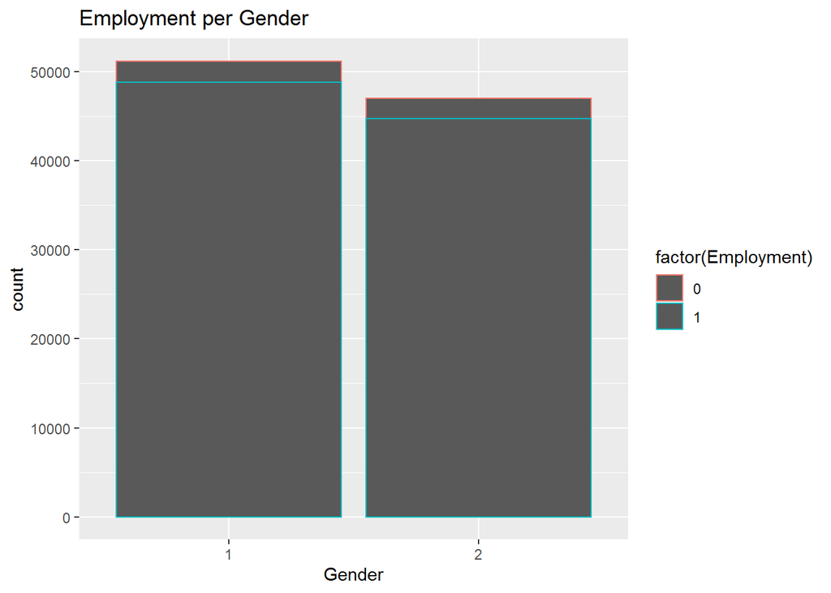

```r
ggplot(emp_racedf, aes(x= SEX, color = factor(Employment))) + geom_bar() +
  ggtitle("Employment per Gender") +
  xlab("Gender")
```

$Note:$: Sex shows no large discrepancies with employment.

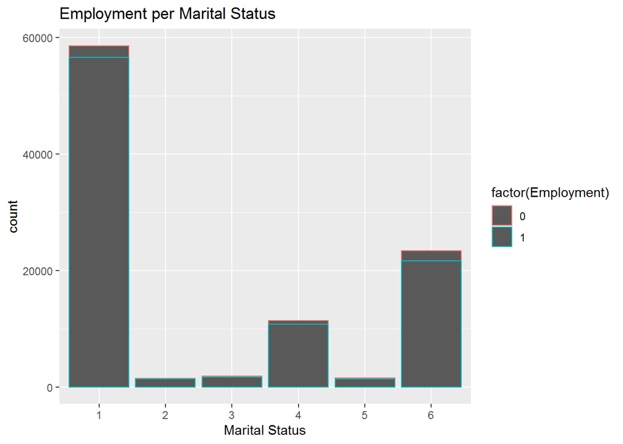

```r
ggplot(emp_racedf, aes(x= MARST, color = factor(Employment))) + geom_bar() +
  ggtitle("Employment per Marital Status") +
  xlab("Marital Status")
```

$Note:$: Marital status shows no large discrepancies with employment.

While the above analysis looks at pre and post Covid together the next part examines employment changes over time.

### *Drop in total employment*

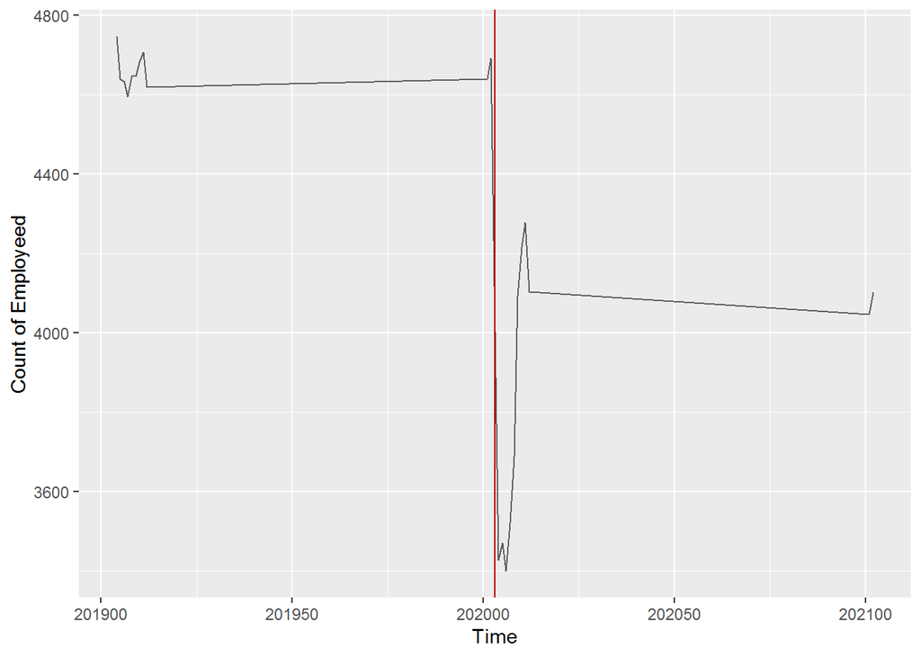

```r
agg <- emp_racedf %>%
  group_by(yearmo) %>%
  summarise(employed_count = sum(as.numeric(Employment))) %>%
  arrange(., yearmo)
ggplot(data=agg, aes(y = employed_count, x = yearmo))+
  geom_line(alpha = 0.6)+
  geom_vline(xintercept = 202003, colour="#BB0000")+
  labs(y = 'Count of Employeed', x = 'Time')
```

$Note:$ The large fall right after the start of Covid was followed by a large uptick a few months later. ***

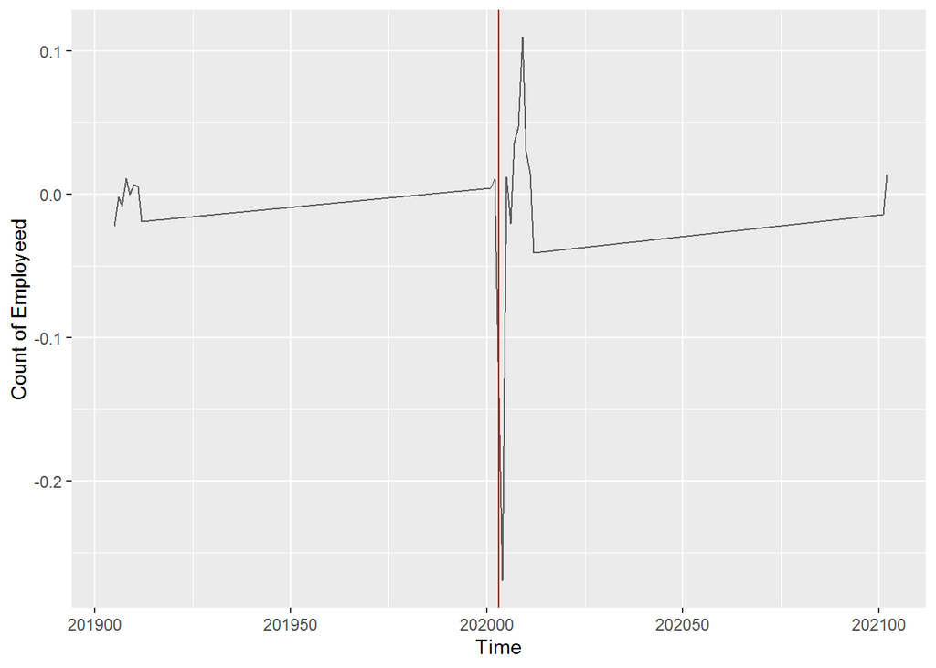

```r
agg <- emp_racedf %>%
  group_by(yearmo) %>%
  summarise(employed_count = sum(as.numeric(Employment))) %>%
  arrange(., yearmo)
agg <- agg %>%
  mutate(lag1_value = lag(employed_count, n=1, order_by=yearmo)) %>%
  mutate(prc_change_emp = (employed_count-lag1_value)/ lag1_value)
ggplot(data=agg, aes(y = prc_change_emp , x = yearmo))+
  geom_line(alpha = 0.6)+
  geom_vline(xintercept = 202003, colour="#BB0000")+
  labs(y = 'Count of Employeed', x = 'Time')
```

# Employment before and after covid

In this section, employment numbers and the % change in employment fluctuations after Covid are explored.

### *Drop by Race*

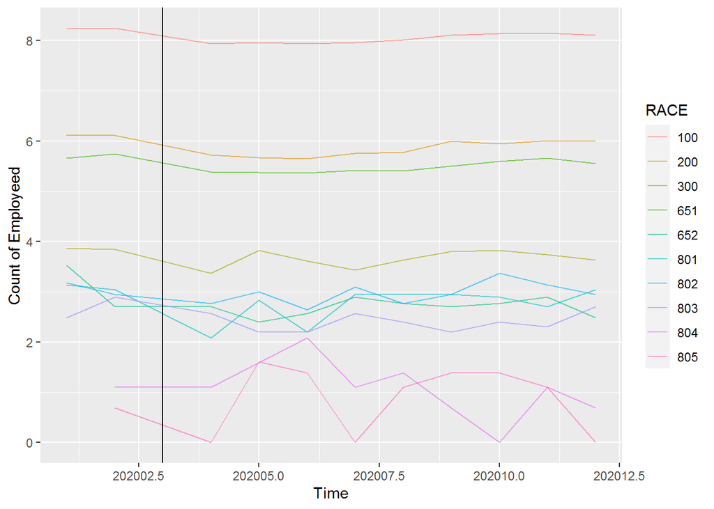

```r
agg <- emp_racedf %>%
  group_by(yearmo, RACE) %>%
  summarise(employed_count = sum(as.numeric(Employment))) %>%
  filter(yearmo >= 201950) %>%
  filter(yearmo <= 202020) %>%
  arrange(.,RACE, yearmo)
ggplot(data=agg, aes(y = log(employed_count), x = yearmo))+
  geom_line(alpha = 0.6, aes(color = factor(RACE)))+
  geom_vline(xintercept = 202003)+
  labs(y = 'Count of Employeed', x = 'Time', color = 'RACE')
```

$Note:$ Most races show a similar level of employment drop, however some races in terms of over all count are more or less employed to begin with, so a similar drop in employment numbers across race might not really be proportional impacts.

To examine this in more detail the % change overtime by race is further explored.

### *% Drop by RACE*

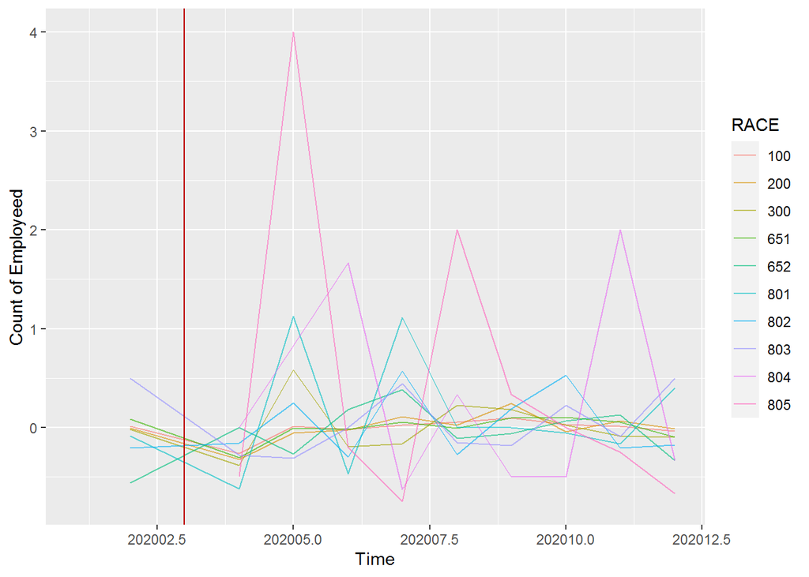

$Note:$ While some races stay relatively steady and correlated to each other, others show high fluctuations. *Some of these are also races with small sample size so a 1 person change in employment makes a large delta in this graph*.

### *Drop by Industry*

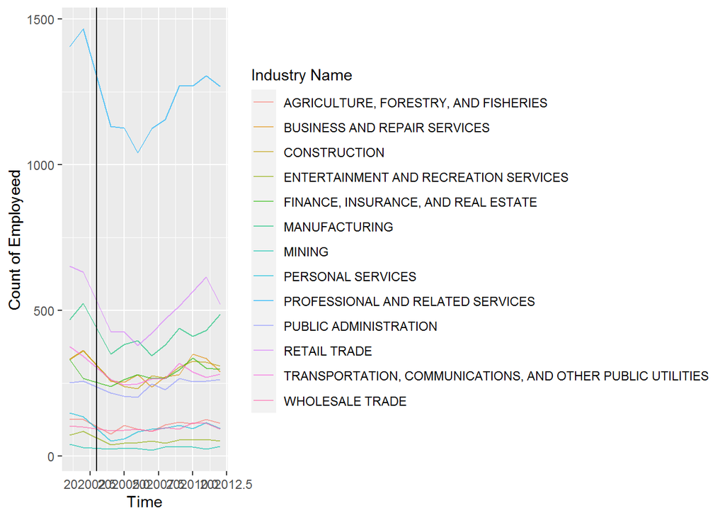

```r
agg <- emp_racedf %>%
  group_by(yearmo, Industry) %>%
  summarise(employed_count = sum(as.numeric(Employment))) %>%
  filter(yearmo >= 201950) %>%
  filter(yearmo <= 202020) %>%
  arrange(.,Industry, yearmo)
ggplot(data=agg, aes(y = employed_count, x = yearmo))+
  geom_line(alpha = 0.6, aes(color = factor(Industry)))+
  geom_vline(xintercept = 202003)+
  labs(y = 'Count of Employeed', x = 'Time', color = 'Industry Name')
```

### *% Drop by Industry*

Taking a look by industry type

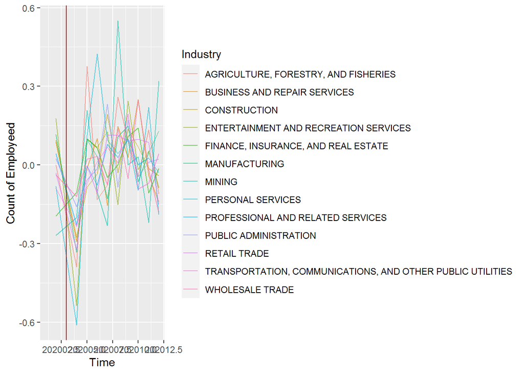

```r
agg <- emp_racedf %>%
  group_by(yearmo, Industry) %>%
  summarise(employed_count = sum(as.numeric(Employment))) %>%
  filter(yearmo >= 201950) %>%
  filter(yearmo <= 202020) %>%
  arrange(., yearmo)
agg <- agg %>%
  group_by(Industry) %>%
  mutate(lag1_value = lag(employed_count, n=1, order_by= yearmo)) %>%
  mutate(prc_change_emp = (employed_count-lag1_value)/ lag1_value) %>%
  arrange(., Industry, yearmo)
ggplot(data=agg, aes(y = prc_change_emp, x = yearmo))+
  geom_line(alpha = 0.6, aes(color = factor(Industry)))+
  geom_vline(xintercept = 202003, colour="#BB0000")+
  labs(y = 'Count of Employeed', x = 'Time', color = 'Industry')
```

### *Drop by age group*

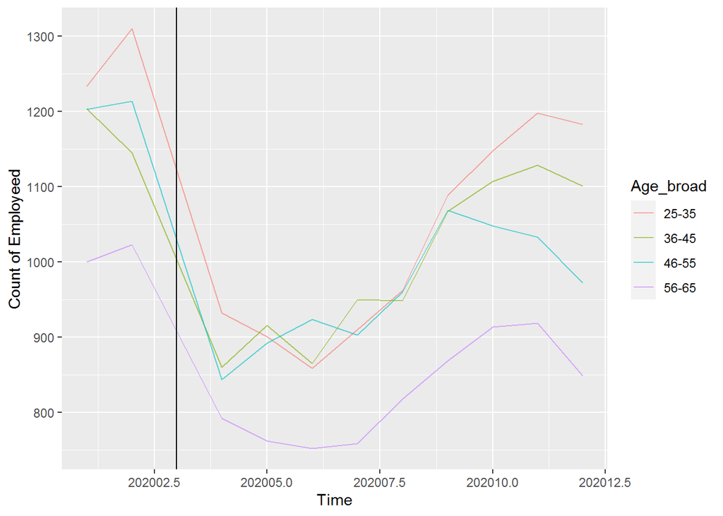

```r
agg <- emp_racedf %>%
  group_by(yearmo,Age_broad) %>%
  summarise(employed_count = sum(as.numeric(Employment))) %>%
  filter(yearmo >= 201950) %>%
  filter(yearmo <= 202020) %>%
  arrange(.,Age_broad, yearmo)
ggplot(data=agg, aes(y = employed_count, x = yearmo))+
  geom_line(alpha = 0.6, aes(color = factor(Age_broad)))+
  geom_vline(xintercept = 202003)+
  labs(y = 'Count of Employeed', x = 'Time', color = 'Age_broad')
```

### *% Drop by age group*

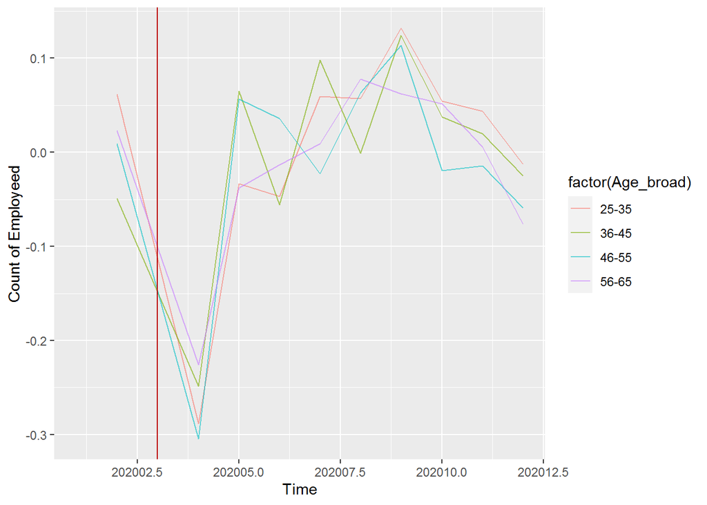

```r
agg <- emp_racedf %>%
  group_by(yearmo, Age_broad) %>%
  summarise(employed_count = sum(as.numeric(Employment))) %>%
  filter(yearmo >= 201950) %>%
  filter(yearmo <= 202020) %>%
  arrange(., yearmo)
agg <- agg %>%
  group_by(Age_broad) %>%
  mutate(lag1_value = lag(employed_count, n=1, order_by= yearmo)) %>%
  mutate(prc_change_emp = (employed_count-lag1_value)/ lag1_value) %>%
  arrange(., Age_broad, yearmo)
ggplot(data=agg, aes(y = prc_change_emp, x = yearmo))+
  geom_line(alpha = 0.6, aes(color = factor(Age_broad)))+
  geom_vline(xintercept = 202003, colour="#BB0000")+
  labs(y = 'Count of Employeed', x = 'Time')
```

$Note:$ After looking at the age groups graphs by count and % we can see that the change across age groups seems to be highly correlated to each other, indicating that one age group does not behave systematically different than that of another.

### *Drop by sex*

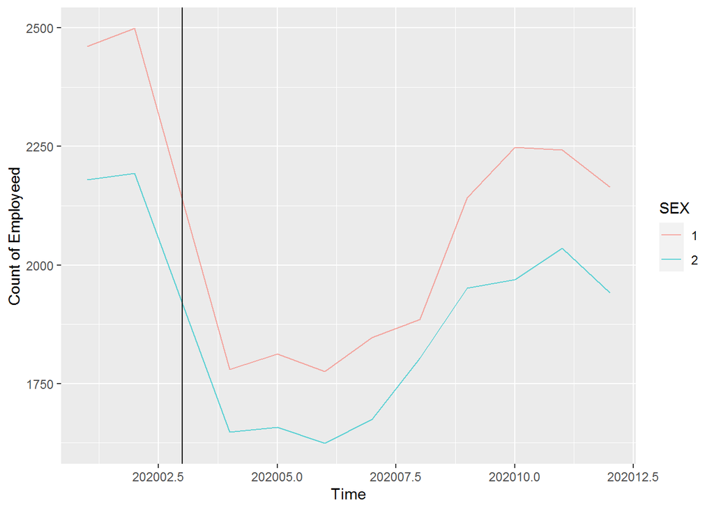

```r
agg <- emp_racedf %>%
  group_by(yearmo,SEX) %>%
  summarise(employed_count = sum(as.numeric(Employment))) %>%
  filter(yearmo >= 201950) %>%
  filter(yearmo <= 202020) %>%
  arrange(.,SEX, yearmo)
ggplot(data=agg, aes(y = employed_count, x = yearmo))+
  geom_line(alpha = 0.6, aes(color = factor(SEX)))+
  geom_vline(xintercept = 202003)+
  labs(y = 'Count of Employeed', x = 'Time', color = 'SEX')
```

# *% Drop by sex*

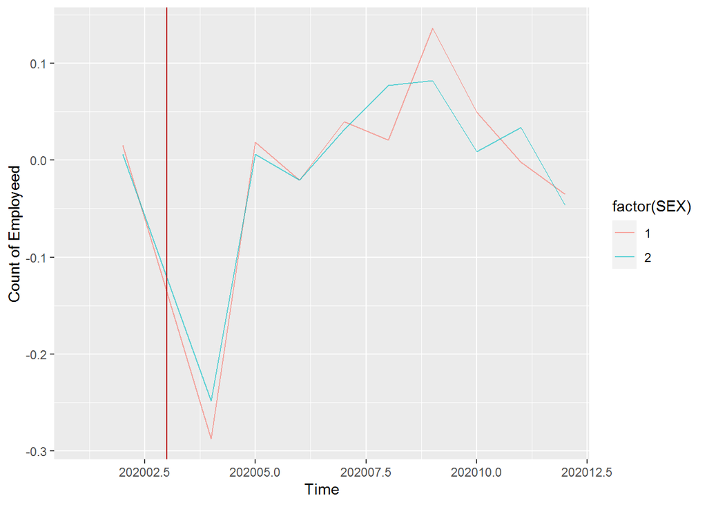

```r
agg <- emp_racedf %>%
  group_by(yearmo, SEX) %>%
  summarise(employed_count = sum(as.numeric(Employment))) %>%
  filter(yearmo >= 201950) %>%
  filter(yearmo <= 202020) %>%
  arrange(., yearmo)
agg <- agg %>%
  group_by(SEX) %>%
  mutate(lag1_value = lag(employed_count, n=1, order_by= yearmo)) %>%
  mutate(prc_change_emp = (employed_count-lag1_value)/ lag1_value) %>%
  arrange(., SEX, yearmo)
ggplot(data=agg, aes(y = prc_change_emp, x = yearmo))+
  geom_line(alpha = 0.6, aes(color = factor(SEX)))+
  geom_vline(xintercept = 202003, colour="#BB0000")+
  labs(y = 'Count of Employeed', x = 'Time')
```

$Note:$ Employment change across sex is also correlated to each other indicating that one group does not behave systematically different than that of another.

### _ Drop by marital status_

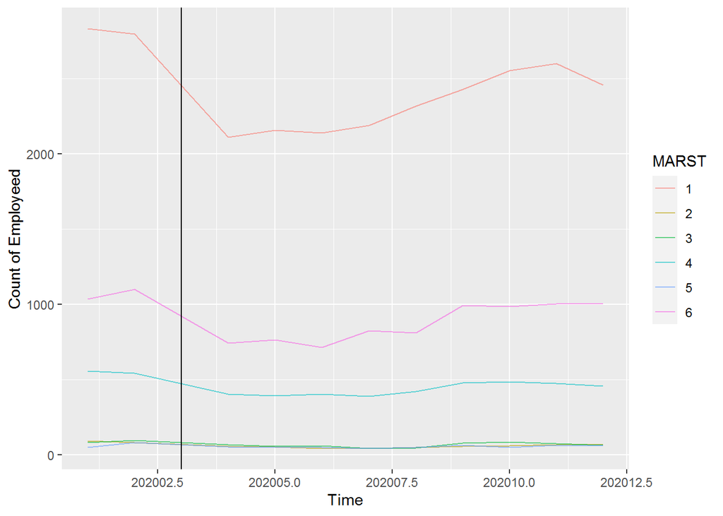

```r
agg <- emp_racedf %>%
  group_by(yearmo, MARST) %>%
  summarise(employed_count = sum(as.numeric(Employment))) %>%
  filter(yearmo >= 201950) %>%
  filter(yearmo <= 202020) %>%
  arrange(.,MARST, yearmo)
ggplot(data=agg, aes(y = employed_count, x = yearmo))+
  geom_line(alpha = 0.6, aes(color = factor(MARST)))+
  geom_vline(xintercept = 202003)+
  labs(y = 'Count of Employeed', x = 'Time', color = 'MARST')
```

### *% Drop by marital status*

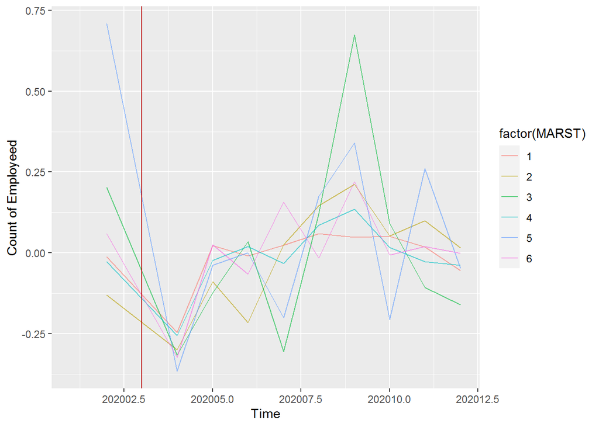

```r
agg <- emp_racedf %>%
  group_by(yearmo, MARST) %>%
  summarise(employed_count = sum(as.numeric(Employment))) %>%
  filter(yearmo >= 201950) %>%
  filter(yearmo <= 202020) %>%
  arrange(., yearmo)
agg <- agg %>%
  group_by(MARST) %>%
  mutate(lag1_value = lag(employed_count, n=1, order_by= yearmo)) %>%
  mutate(prc_change_emp = (employed_count-lag1_value)/ lag1_value) %>%
  arrange(., MARST, yearmo)
ggplot(data=agg, aes(y = prc_change_emp, x = yearmo))+
  geom_line(alpha = 0.6, aes(color = factor(MARST)))+
  geom_vline(xintercept = 202003, colour="#BB0000")+
  labs(y = 'Count of Employeed', x = 'Time')
```

$Note:$ Employment change across marital is also correlated to each other indicating that one group does not behave systematically different than that of another.

Based on the SEX, AGE graphical relationship we can see that they move in sync, marital status however has more variation in select statuses. Due to these findings Age and sex variables were dropped from the further analyses.